# Autocorrelation in Group Size

2017-10-06

## Set up environment

```r
# Load packages and make connections to babase
Sys.setenv(TZ = 'UTC')
list.of.packages <- list("devtools", "viridis", "tidyverse", "stringr",
                         "lubridate")
new.packages <- list.of.packages[!(list.of.packages %in% installed.packages()[,"Package"])]
if (length(new.packages)) install.packages(unlist(new.packages))
lapply(list.of.packages, require, character.only = T)

# Check if ramboseli already installed
if (!("ramboseli" %in% installed.packages()[,"Package"])) {
  devtools::install_github("amboseli/ramboseli")
}
library(ramboseli)
```

## Obtain data from babase

*This will not work with “live” babase data until you have set up a connection between R and babase!*

This entails getting a papio login, and creating an ssh tunnel from your computer to papio in putty (Windows) or terminal (Mac/Unix).

## Creating the connections

On my machine, I type something like this into terminal to make the ssh tunnel:

`ssh -f fac13@papio.biology.duke.edu -L 2222:localhost:5432 -N`

You wil obviously need to change the username before the @ symbol. If you get that sorted out, you can create a connection to babase using the code below. These lines create *connections* to babase tables and then pull data into R. It doesn’t actually collect any data until the very end so that database backend does the heavy lifting. In this approach, you’re essentially specifying joins among your table connections, sending the query to the database to execute, and collecting the result.

Alternatively, you can write a query in SQL, run it in babase, output to csv, and load that into R into a variable called “kids”.

```r
# You will need to change user to your personal babase login AND get your password
# One approach to doing that is through Rstudio
# You could also just type it in your script, but that's not recommended for security.
babase <- DBI::dbConnect(RPostgreSQL::PostgreSQL(),
                         host = "localhost",
                         port = 2222,
                         user = "YOUR_BABASE_USERNAME",
                         dbname = "babase",
                         password = rstudioapi::askForPassword("Database password"))

# Remote data sources in babase
members <- tbl(babase, "members")
biograph <- tbl(babase, "biograph")
maturedates <- tbl(babase, "maturedates")
parents <- tbl(babase, "parents")
maternities <- tbl(babase, "maternities")
pregs <- tbl(babase, "pregs")
statuses <- tbl(babase, "statuses")

# Local copy of members for using in joins
members_local <- collect(members)
```

## Experienced group size

In this section, we find the group size that each individual female experienced on each “monthly birthday” throughout her life.

Steps:

1. Find all live-born females born into study population
2. Create sequence of 1-month time steps for each female from date of birth until her last “monthly birthday” before death.
3. Obtain total group size for the female on each date from the members table

### Create age sequences

```r
# Find all live-born offspring with known mother
kids <- biograph %>%
  inner_join(select(parents, kid, mom), by = c("sname" = "kid")) %>%
  left_join(select(pregs, pid, parity), by = "pid") %>%
  inner_join(select(biograph, mom = sname, mom_dob = birth), by = "mom") %>%
  rename(kid = sname) %>%
  filter(sex == "F") %>%
  collect()

# Calculate age at depart
kids <- kids %>%
  mutate(age_depart = interval(birth, statdate) %/% days(1) / 365.25)

# Function to create a sequence of ages (in years) for each individual
# From 0(birth) to last birthday before departure
get_age_seq <- function(df) {
  return(seq(0, floor(df$age_depart)))
}

# As above, but in monthly time steps
get_age_seq_months <- function(df) {
  return(seq(0, floor(df$age_depart * 12)))
}

# Create a data frame for holding these sequences of ages
# For each kid, apply the get_age_seq functions and store the results
age_seq <- kids %>%
  group_by(kid) %>%
  nest() %>%
  mutate(age_seq = map(data, get_age_seq),
         age_seq_months = map(data, get_age_seq_months)) %>%
  select(kid, age_seq_months) %>%
  unnest()

# Expand kids to create row for each census age for that individual in age_seq
kid_seq <- kids %>%
  inner_join(select(age_seq, kid, age_months = age_seq_months), by = "kid")

kid_seq$census_day <- kid_seq$birth %m+% months(kid_seq$age_months)
```

### Match to group sizes

```r
# Find group on birthday
kid_seq <- kid_seq %>%
  left_join(select(members_local, kid = sname, census_day = date, current_grp = grp),
            by = c("kid", "census_day"))

# Find all members present on census_day
members_on_census <- kid_seq %>%
  left_join(members_local, by = c("current_grp" = "grp", "census_day" = "date"))

# Count members on census day
n_on_census <- members_on_census %>%
  mutate(age = age_months / 12) %>%
  group_by(kid, census_day, sex, age, age_months, current_grp) %>%
  summarise(n = n())

# Get group size on date of birth
n_on_bdate <- n_on_census %>%
  ungroup() %>%
  filter(age_months == 0) %>%
  select(kid, n_on_bdate = n)

# Join to n_on_census --> adds n_on_bdate column
n_on_census <- n_on_census %>%
  inner_join(n_on_bdate, by = "kid")

# Change all counts for group 9 to NA, since we don't really know
n_on_census$n <- ifelse(n_on_census$current_grp == 9, NA, n_on_census$n)

# Calculate incremental and total change in group size, time diff
# grp_increment = from previous census to current census
# grp_change = from birth to current census
# time_diff = time elapsed from previous census to current census
n_on_census <- n_on_census %>%
  ungroup() %>%
  arrange(kid, age_months) %>%
  group_by(kid) %>%
  mutate(grp_increment = n - lag(n),
         grp_change = n - n_on_bdate,
         time_diff = census_day - lag(census_day))

# Define group size categories in increments of 10
n_on_census$bdate_grp_size <- cut(n_on_census$n_on_bdate,
                                  breaks = seq(0, 120, 10))
```

### Plot of experienced group size.

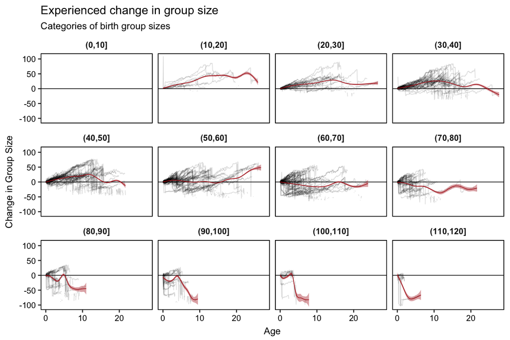

```r
ggplot() +
  geom_line(data = n_on_census,
            aes(x = age, y = grp_change, group = kid),
            alpha = 0.15) +
  geom_hline(yintercept = 0) +
  stat_smooth(data = n_on_census,
              aes(x = age, y = grp_change),
              color = "firebrick", fill = "firebrick", size = 0.5) +
  facet_wrap(~bdate_grp_size) +
  theme_journal_x2() +
  labs(x = "Age", y = "Change in Group Size",
       title = "Experienced change in group size",
       subtitle = "Categories of birth group sizes")
```

## Autocorrelation

In this section, we apply an autocorrelation function to each individual female’s experienced group size over her life. We’re going to average this across individuals of different birth group sizes.

If, for example, being born in a small group is a reliable signal that the adult social environment is likely to be a large group 10 years latter, that would appear as negative autocorrelation at lag 10 years.

### Apply ACF to individuals

```r
# Make nested df for applying acf function to each kid
grp_size_acf <- n_on_census %>%
  ungroup() %>%
  group_by(kid, bdate_grp_size) %>%
  nest()

# Function to apply R's acf function on df
# Only returns the vector of acf values
get_acf <- function(df) {
  res <- acf(df$n, plot = FALSE, na.action = na.pass, lag.max = 120)$acf[,,1]
}

# Apply the function to each nested df, store result in new column called acf
grp_size_acf <- grp_size_acf %>%
  mutate(acf = map(data, get_acf))

# Drop the column called data, and unnest
# Also add a row number, which is the lag (in months)
grp_size_acf <- grp_size_acf %>%
  select(kid, bdate_grp_size, acf) %>%
  unnest() %>%
  group_by(kid) %>%
  mutate(lag = row_number() - 1)

# Summarize, with set sizes and mean
grp_size_acf_summary <- grp_size_acf %>%
  group_by(bdate_grp_size, lag) %>%
  mutate(set_size = n(),
         mean = mean(acf, na.rm = TRUE))
```

### Plot of individual ACF

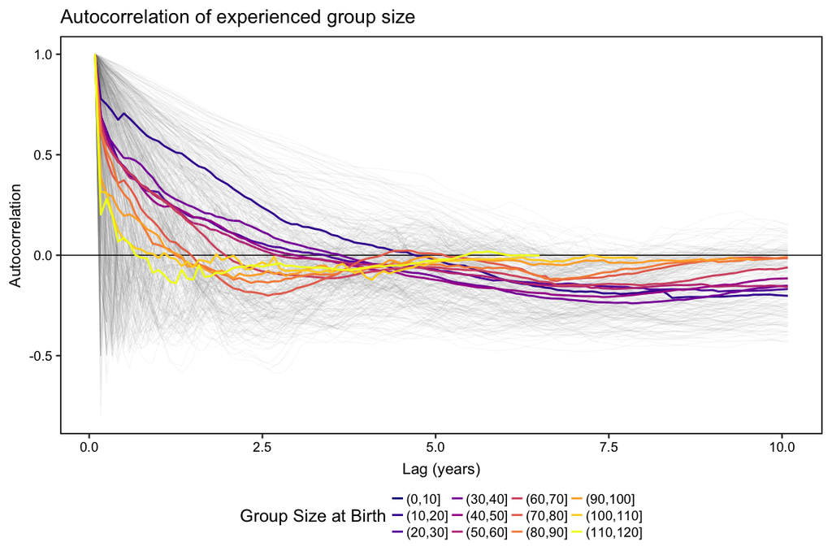

```r
ggplot() +
  geom_line(data = grp_size_acf,
            aes(x = lag / 12, y = acf, group = kid),
            size = 0.1, alpha = 0.25, color = "gray50") +
  geom_hline(yintercept = 0) +
  geom_line(data = grp_size_acf_summary,
            aes(x = lag / 12, y = mean, group = bdate_grp_size,
                color = bdate_grp_size), size = 1) +
  scale_color_manual(values = viridis::viridis(12, option = "plasma"),
                     name = "Group Size at Birth") +
  # facet_wrap(~bdate_grp_size) +
  theme_journal_x2() +
  labs(x = "Lag (years)", y = "Autocorrelation",
       title = "Autocorrelation of experienced group size")
```